# Example Report

Suzanne Dufault, PhD

2021-06-30

## R Markdown

This is an R Markdown file. The benefits of working out of a document like this is that you can easily write in normal text *and* run code. It’s a good place to keep track of the code that you need and any annotation or thoughts on the results. It’s like a Stata .do file, but prettier and a bit more powerful.

## Data

In this first code “chunkâ€?, I am going to call in the data sample and look at the first 5 rows.

```r
# Call in the data
load("2021-06-30_awed-spatial-sample.RData")

# Look at the first 5 lines
head(awed_slice, n = 5) %>%
  # Make a pretty table
  kable() %>%
  kable_styling()
```

| participant_id_shuffled | enrolment_date | illness_onset | cluster | intervention | dengue | longitude | latitude | serotype | age_shuffled | sex_shuffled |
| --- | --- | --- | --- | --- | --- | --- | --- | --- | --- | --- |
| id13-00078 | 2018-10-11 03:48:20 | 2018-10-08 | 11 | 0 | 0 | 110.3577 | -7.797687 | test-negative control | 6.121834 | 1 |
| id11-00270 | 2019-03-01 03:22:01 | 2019-02-28 | 7 | 1 | 0 | 110.3686 | -7.793548 | test-negative control | 18.031485 | 1 |
| id11-00064 | 2018-08-25 03:38:40 | 2018-08-23 | 3 | 0 | 0 | 110.3601 | -7.783194 | test-negative control | 12.366872 | 0 |
| id18-00334 | 2019-01-15 02:29:10 | 2019-01-11 | 6 | 1 | 0 | 110.3610 | -7.795807 | test-negative control | 7.085558 | 0 |
| id07-00894 | 2019-05-20 02:21:53 | 2019-05-18 | 12 | 1 | 0 | 110.3525 | -7.810052 | test-negative control | 7.638604 | 1 |

Here are some simple summaries:

```r
# The number of test-negatives (dengue = 0) and test-positives (dengue = 1) in the dataset
table(awed_slice$dengue)
```

```
##
##    0    1
## 1973  130
```

There are 1,973 test-negatives and 130 test-positives in this sample of the dataset.

```r
# This is kind of an ugly summary, but it gives you the basic information
summary(awed_slice)
```

```
##  participant_id_shuffled enrolment_date
##  Length:2103             Min.   :2018-01-08 02:16:00
##  Class :character        1st Qu.:2018-11-19 04:35:56
##  Mode  :character        Median :2019-03-21 02:07:21
##                          Mean   :2019-03-30 18:17:42
##                          3rd Qu.:2019-10-05 03:53:00
##                          Max.   :2020-03-18 04:08:13
##  illness_onset                    cluster       intervention
##  Min.   :2018-01-04 00:00:00   Min.   : 1.00   Min.   :0.0000
##  1st Qu.:2018-11-18 00:00:00   1st Qu.: 6.00   1st Qu.:0.0000
##  Median :2019-03-19 00:00:00   Median :11.00   Median :0.0000
##  Mean   :2019-03-28 09:47:30   Mean   :10.84   Mean   :0.4565
##  3rd Qu.:2019-10-03 00:00:00   3rd Qu.:14.00   3rd Qu.:1.0000
##  Max.   :2020-03-16 00:00:00   Max.   :24.00   Max.   :1.0000
##      dengue          longitude        latitude        serotype
##  Min.   :0.00000   Min.   :110.4   Min.   :-7.836   Length:2103
##  1st Qu.:0.00000   1st Qu.:110.4   1st Qu.:-7.810   Class :character
##  Median :0.00000   Median :110.4   Median :-7.802   Mode  :character
##  Mean   :0.06182   Mean   :110.4   Mean   :-7.802
##  3rd Qu.:0.00000   3rd Qu.:110.4   3rd Qu.:-7.792
##  Max.   :1.00000   Max.   :110.4   Max.   :-7.776
##   age_shuffled     sex_shuffled
##  Min.   : 3.025   Min.   :0.0000
##  1st Qu.: 7.036   1st Qu.:0.0000
##  Median :12.337   Median :0.0000
##  Mean   :15.230   Mean   :0.4798
##  3rd Qu.:21.222   3rd Qu.:1.0000
##  Max.   :45.873   Max.   :1.0000
```

In the summary, we see that in this sample of the AWED data, there are 11 variables.

- participant_id_shuffled - a character vector containing the shuffled participant ids
- enrolment_date - the date of enrolment. First enrolled participant was on January 8, 2018. Last enrolled participant was enrolled on March 18, 2020.
- illness_onset - the reported date of illness onset. First illness onset was January 4, 2018. Last illness onset was March 16, 2020.
- cluster - the AWED study cluster containing the participant’s home address (labelled 1-24)
- intervention - whether the cluster was untreated (intervention = 0) or treated with wMel-carrying Ae. aegypti deployments (intervention = 1)
- dengue - whether the participant tested negative for dengue (dengue = 0) or tested positive for dengue (dengue = 1)
- longitude - of home location
- latitude - of home location
- serotype - either test-negative, the identified dengue serotype (DENV1-DENV4), or unknown dengue serotype (unable to identify)
- age_shuffled
- sex_shuffled

## Maps

Here, the code gets a bit complicated so I have hidden it from the output for now. Basically, I’m tidying up the data so that it will make a pretty map.

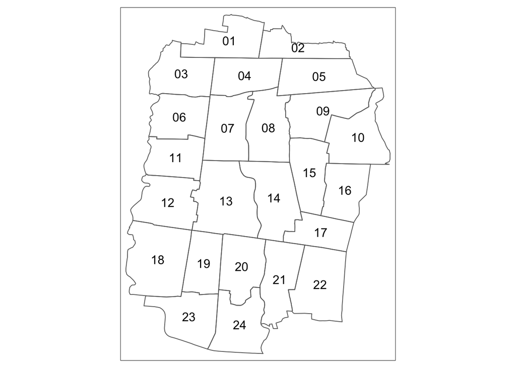

```r
# A look at the preliminary map of the study area
map_yogya <-
  tm_shape(Yogya_Adm_1) +
  tm_borders()

map_yogya +
  tm_text(text = "New_Clustr")
```

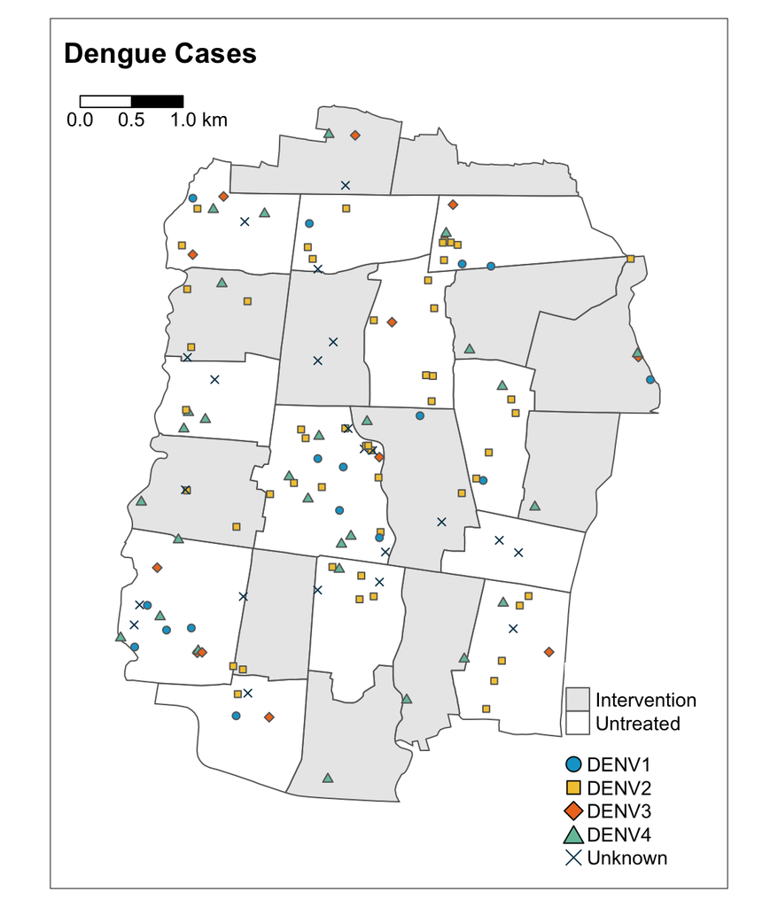

```r
# Dengue point plot
map_yogya +
  tm_polygons(col = "Intervention",
              alpha = 0.5,
              palette = c("lightgray", "white")) +
  tm_shape(subset(CRTND_dengue_data_SPDF, dengue == 1)) +
  tm_symbols(col = "serotype",
          shape = "serotype",
          legend.col.show = FALSE,
          legend.shape.show = FALSE,
          palette = df_col_sero$sero.color,
          shapes = df_col_sero$sero.shape,
          size = 0.15) +
  tm_add_legend("symbol",
                col = df_col_sero$sero.color[1:5],
                shape = df_col_sero$sero.shape[1:5],
                labels = df_col_sero$serotype[1:5]) +
  tm_layout(legend.text.size = 0.9,
            legend.title.size = 1,
            legend.title.color = "white",
            inner.margins = 0.1,
            title = "Dengue Cases",
            title.fontface = "bold") +
  tm_scale_bar(breaks = c(0,.50,1.00), text.size = 0.9, position = c("left", "top"))
```

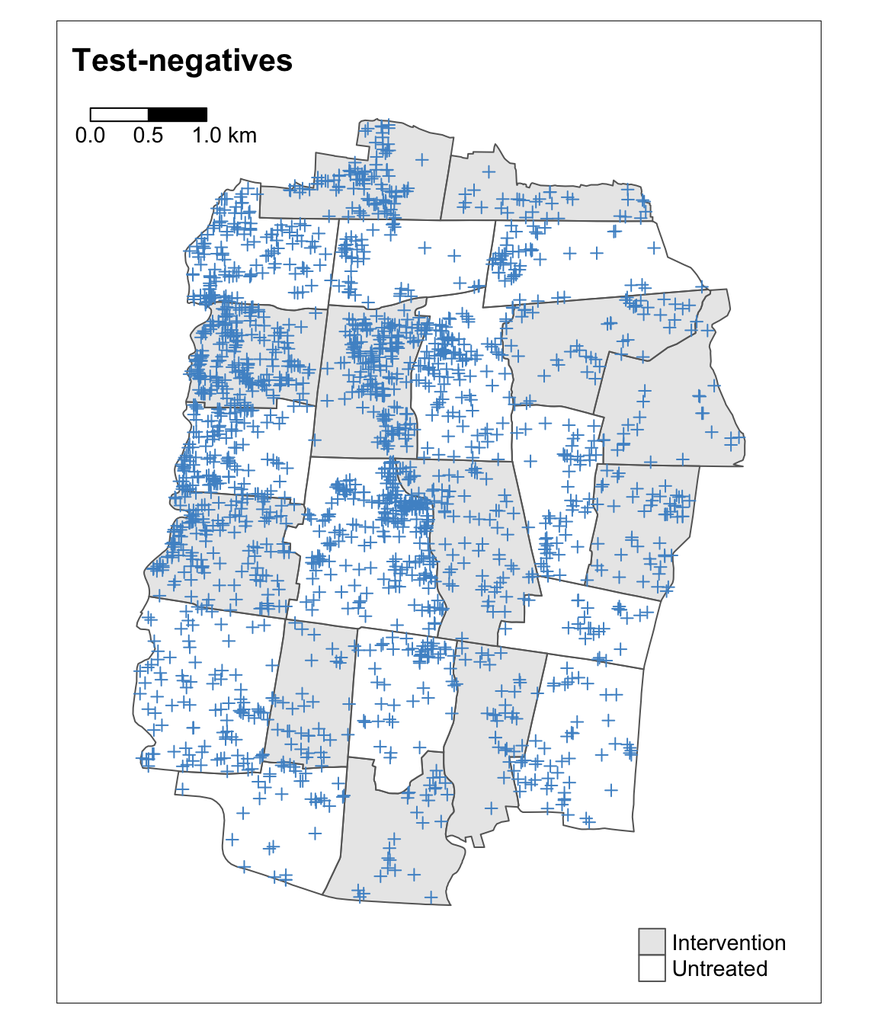

```r
# Test-negative point plot
map_yogya +
  tm_polygons(col = "Intervention",
              alpha = 0.5,
              palette = c("lightgray", "white")) +
  tm_shape(subset(CRTND_dengue_data_SPDF, dengue == 0)) +
  tm_symbols(shape = 3,
             col = "steelblue3",
          size = 0.15) +
  tm_layout(legend.text.size = 0.9,
            legend.title.size = 1,
            legend.title.color = "white",
            inner.margins = 0.1,
            title = "Test-negatives",
            title.fontface = "bold") +
  tm_scale_bar(breaks = c(0,.50,1.00), text.size = 0.9, position = c("left", "top"))
```